# Multiple Linear Regression

Author

Dr Omar, Dr Zaim, Dr Hafiz, Dr Syuaib

# 1 Introduction : Chapter 1

## 1.1 Team Member :

Dr Omar Bin Nazmi

Dr Muhammad Zaim Bin Muhd Samsuri

Dr Mohd Abdul Hafiz Bin Kamarul Zaman

Dr Syuaib Aiman Amir bin Kamarudin

## 1.2 Workflow

### 1.2.1 Datasets

This exercise will use dataset mental health literacy, The dataset belonged to a study on mental health literacy among house officers. The followings are regarding the datasets:

1. ID : Subject’s ID.
2. Age : Respondents’s Age (Numerical variable)
3. Gender : gender (Categorical) , (labelled ; Male, female)
4. Current Hospital Posting : (Categorical)
5. Duration of employment : ( Numerical)
6. Marital Status : (Categorical)
7. Previous experiences of being bullied: (Categorical)
8. Family members spouse: (Categorical)
9. Peers friends: ( Categorical)

Literature review shows Age, female gender, Hospital with good mental support, duration of employment, marital status, previous experiences of being bullied, family member spouse who are supportive, and peerd friends shows better mental health literacy.

## 1.3 Prepare the Environment

### 1.3.1 Install packages

```r
library(tidyverse)
library(here)
library(broom)
library(broom.helpers)
library(haven)
library(gtsummary)
library(dplyr)
library(corrplot)
library(knitr)
library(readxl)
library(janitor)
library(skimr)
library(GGally)
library(rsq)
```

### 1.3.2 Read Data

```r
data1 <- read_excel("C:/Users/H P/OneDrive - The Goose and Duck/Desktop/mlinear final/Data1.xlsx")
data1<-clean_names(data1)
summary(data1)
```

```
       id        current_hospital_posting      age           gender
 Min.   :  1.0   Length:299               Min.   :25.00   Length:299
 1st Qu.: 75.5   Class :character         1st Qu.:26.00   Class :character
 Median :151.0   Mode  :character         Median :27.00   Mode  :character
 Mean   :150.6                            Mean   :26.86
 3rd Qu.:225.5                            3rd Qu.:27.00
 Max.   :300.0                            Max.   :34.00
 marital_status     duration_of_employment previous_experience_of_being_bullied
 Length:299         Min.   : 4.00          Length:299
 Class :character   1st Qu.: 8.00          Class :character
 Mode  :character   Median :12.00          Mode  :character
                    Mean   :13.34
                    3rd Qu.:18.00
                    Max.   :24.00
 family_members_spouse peers_friends      literacy_score
 Length:299            Length:299         Min.   : 75.00
 Class :character      Class :character   1st Qu.: 94.00
 Mode  :character      Mode  :character   Median : 98.00
                                          Mean   : 99.26
                                          3rd Qu.:104.00
                                          Max.   :155.00
```

```r
glimpse(data1)
```

```
Rows: 299
Columns: 10
$ id                                   <dbl> 1, 2, 3, 4, 5, 6, 7, 8, 9, 10, 11…
$ current_hospital_posting             <chr> "HSIP", "HSIP", "HSIP", "HSIP", "…
$ age                                  <dbl> 27, 26, 25, 26, 27, 26, 27, 29, 3…
$ gender                               <chr> "Female", "Female", "Female", "Fe…
$ marital_status                       <chr> "Single", "Single", "Single", "Si…
$ duration_of_employment               <dbl> 10, 9, 9, 9, 10, 8, 10, 23, 9, 9,…
$ previous_experience_of_being_bullied <chr> "No", "No", "Yes", "No", "Yes", "…
$ family_members_spouse                <chr> "No", "No", "Yes", "No", "No", "N…
$ peers_friends                        <chr> "No", "No", "Yes", "No", "Yes", "…
$ literacy_score                       <dbl> 102, 105, 102, 107, 111, 98, 97, …
```

### 1.3.3 Data exploration

#### 1.3.3.1 Descriptive

```r
data2<-
  data1 %>%
  mutate(across(where(is.character),as.factor))
```

```r
data2 <- data2 %>%
  mutate(age = as.numeric(as.character(age)))
```

```r
data2 <- data2 %>%
  mutate(age = as.integer(age))
```

```r
data2 %>%
  select(duration_of_employment, current_hospital_posting, previous_experience_of_being_bullied, family_members_spouse, peers_friends, literacy_score)
```

```
# A tibble: 299 × 6
   duration_of_employment current_hospital_posting previous_experience_of_bein…¹
                    <dbl> <fct>                    <fct>
 1                     10 HSIP                     No
 2                      9 HSIP                     No
 3                      9 HSIP                     Yes
 4                      9 HSIP                     No
 5                     10 HSIP                     Yes
 6                      8 HSIP                     Yes
 7                     10 HSIP                     No
 8                     23 HSIP                     No
 9                      9 HSIP                     No
10                      9 HSIP                     No
# ℹ 289 more rows
# ℹ abbreviated name: ¹previous_experience_of_being_bullied
# ℹ 3 more variables: family_members_spouse <fct>, peers_friends <fct>,
#   literacy_score <dbl>
```

```r
str(data2)
```

```
tibble [299 × 10] (S3: tbl_df/tbl/data.frame)
 $ id                                  : num [1:299] 1 2 3 4 5 6 7 8 9 10 ...
 $ current_hospital_posting            : Factor w/ 4 levels "HRPZ","HSIP",..: 2 2 2 2 2 2 2 2 2 2 ...
 $ age                                 : int [1:299] 27 26 25 26 27 26 27 29 31 28 ...
 $ gender                              : Factor w/ 2 levels "Female","Male": 1 1 1 1 1 1 1 1 1 1 ...
 $ marital_status                      : Factor w/ 2 levels "Married","Single": 2 2 2 2 2 2 2 1 1 2 ...
 $ duration_of_employment              : num [1:299] 10 9 9 9 10 8 10 23 9 9 ...
 $ previous_experience_of_being_bullied: Factor w/ 2 levels "No","Yes": 1 1 2 1 2 2 1 1 1 1 ...
 $ family_members_spouse               : Factor w/ 2 levels "No","Yes": 1 1 2 1 1 1 1 1 1 1 ...
 $ peers_friends                       : Factor w/ 2 levels "No","Yes": 1 1 2 1 2 1 1 1 1 2 ...
 $ literacy_score                      : num [1:299] 102 105 102 107 111 98 97 98 108 84 ...
```

```r
# Change the reference level for the gender factor
data2$gender <- relevel(data2$gender, ref = "Male")
# Check the levels to confirm the change
levels(data2$gender)
```

```
[1] "Male"   "Female"
```

According to the literature review, gender female are better in mental health literacy compared to gender male.

#### 1.3.3.2 Summary data

```r
data2 %>%
  tbl_summary(
    label = list(
      duration_of_employment ~ "Duration of employment",
      age~"Age",
      current_hospital_posting ~ "Current hospital posting",
      previous_experience_of_being_bullied ~ "Previous experience",
      family_members_spouse ~ "Family members",
      peers_friends ~ "Peers",
      literacy_score ~ "Literacy score"
    ),
    statistic = list(
      all_continuous() ~ "{mean} ({sd})"
    )
  ) %>%
  bold_labels() %>%
  italicize_levels()
```

| **Characteristic** | **N = 299**<sup>1</sup> |
| --- | --- |
| id | 151 (87) |
| Current hospital posting |  |
| HRPZ | 96 (32%) |
| HSIP | 57 (19%) |
| HTM | 38 (13%) |
| HUSM | 108 (36%) |
| Age |  |
| 25 | 24 (8.0%) |
| 26 | 106 (35%) |
| 27 | 106 (35%) |
| 28 | 40 (13%) |
| 29 | 12 (4.0%) |
| 30 | 4 (1.3%) |
| 31 | 4 (1.3%) |
| 32 | 1 (0.3%) |
| 34 | 2 (0.7%) |
| gender |  |
| Male | 109 (36%) |
| Female | 190 (64%) |
| marital_status |  |
| Married | 47 (16%) |
| Single | 252 (84%) |
| Duration of employment | 13.3 (5.9) |
| Previous experience | 91 (30%) |
| Family members | 31 (10%) |
| Peers | 87 (29%) |
| Literacy score | 99 (8) |

<sup>1</sup> Mean (SD); n (%)

#### 1.3.3.3 Explore and Wrangle Data

1. Age

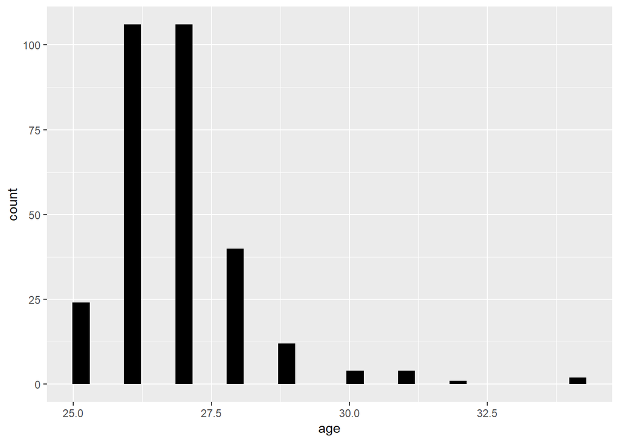

```r
ggplot(data = data2,aes(age))+
  geom_histogram(fill= "black")
```

```r
geom_boxplot()
```

```
geom_boxplot: outliers = TRUE, outlier.colour = NULL, outlier.fill = NULL, outlier.shape = 19, outlier.size = 1.5, outlier.stroke = 0.5, outlier.alpha = NULL, notch = FALSE, notchwidth = 0.5, staplewidth = 0, varwidth = FALSE, na.rm = FALSE, orientation = NA
stat_boxplot: na.rm = FALSE, orientation = NA
position_dodge2
```

2. Gender

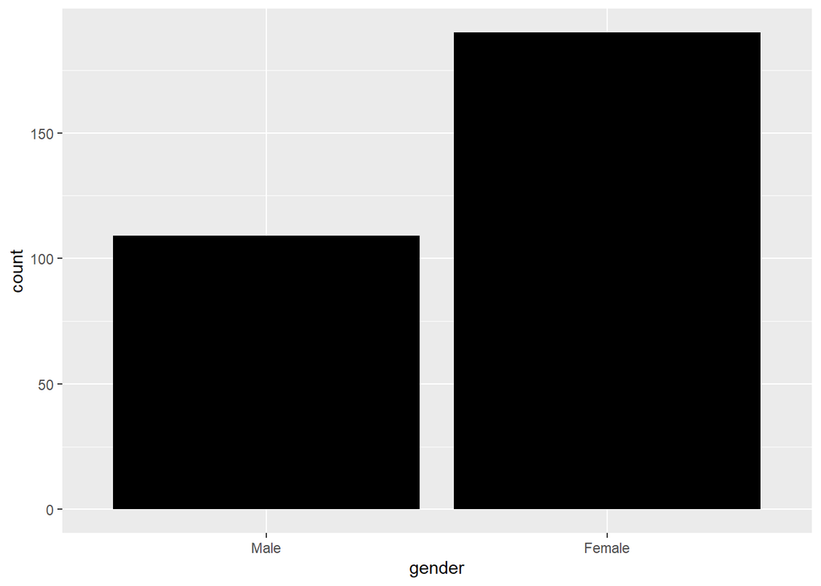

```r
ggplot(data2, aes(x = gender)) +
  geom_bar( fill= "black")
```

3. Current Hospital Posting

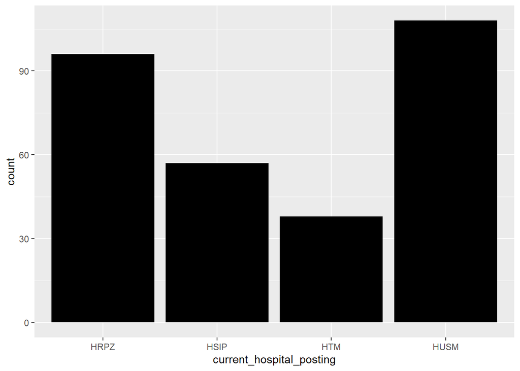

   ```r
   ggplot(data2, aes(x = current_hospital_posting )) +
     geom_bar(fill= "black")
   ```

4. Duration of employment

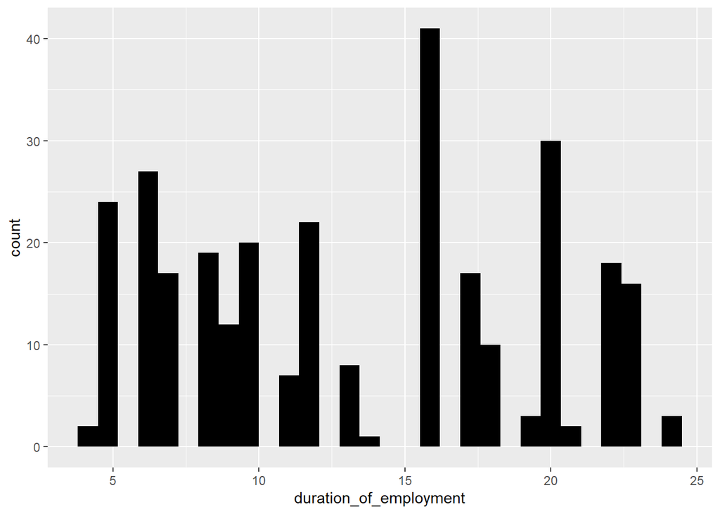

   ```r
   ggplot(data = data2,aes(duration_of_employment))+
     geom_histogram(fill ="black")
   ```

5. Marital status

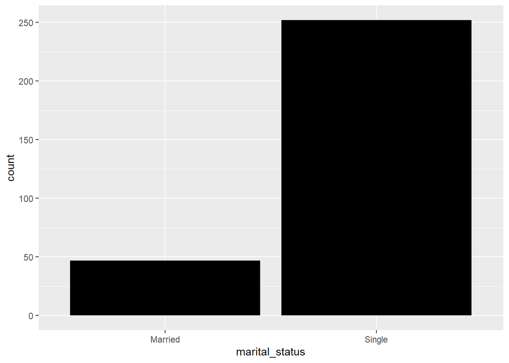

   ```r
   ggplot(data2, aes(x = marital_status)) +
     geom_bar( fill= "black")
   ```

6. Previous Experiences Being Bullied

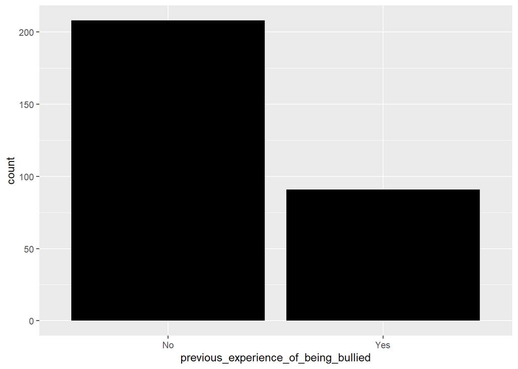

   ```r
   ggplot(data2, aes(x = previous_experience_of_being_bullied )) +
     geom_bar(fill="black")
   ```

7. Family members spouse

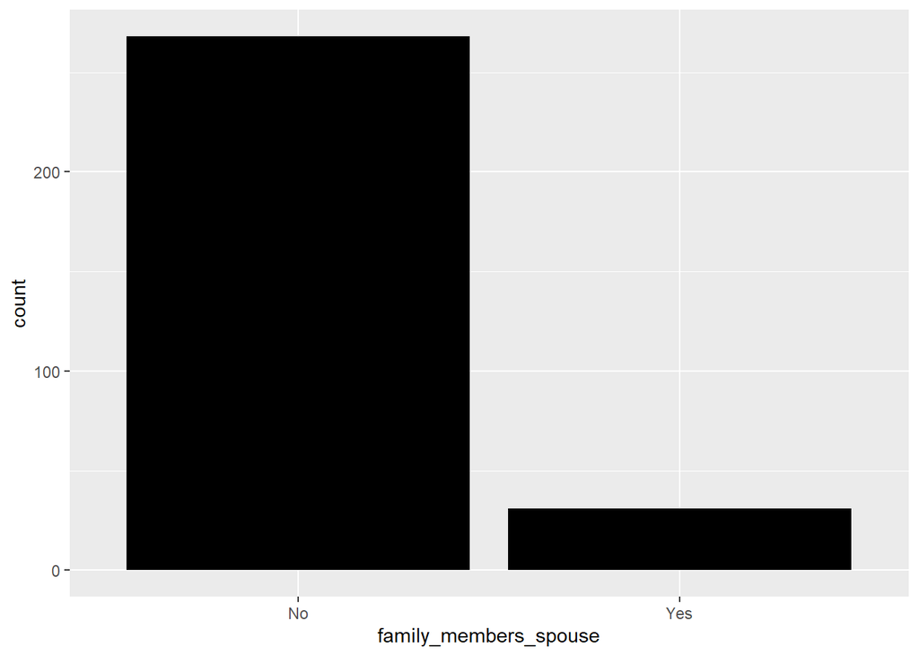

   ```r
   ggplot(data2, aes(x = family_members_spouse  )) +
     geom_bar(fill= "black")
   ```

8. peers friends

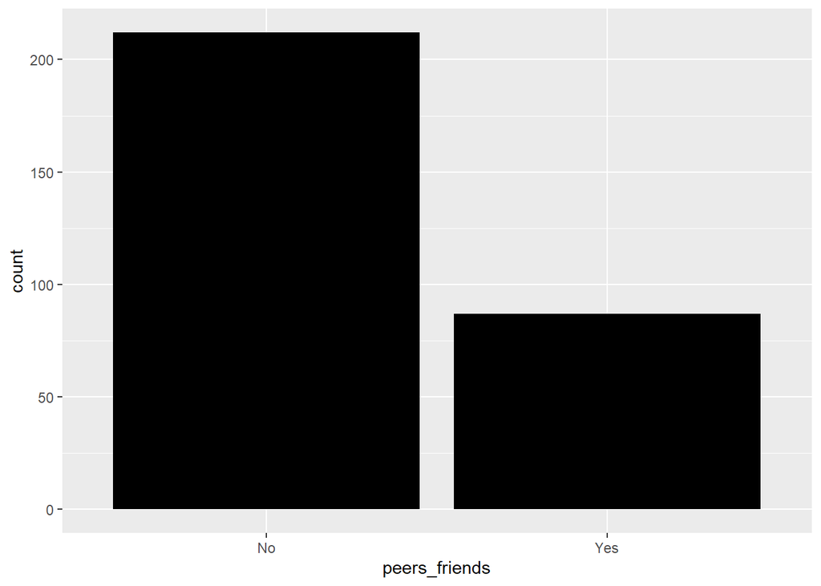

   ```r
   ggplot(data2, aes(x = peers_friends  )) +
     geom_bar(fill= "black")
   ```

### 1.3.4 Check Correlation

```r
data3<-
data2 %>%
select(where(is.numeric), -id)

cor.data3 <-
  cor(data3, use = "complete.obs", method = "pearson")
head(round(cor.data3,2))
```

```
                        age duration_of_employment literacy_score
age                    1.00                   0.34           0.08
duration_of_employment 0.34                   1.00          -0.12
literacy_score         0.08                  -0.12           1.00
```

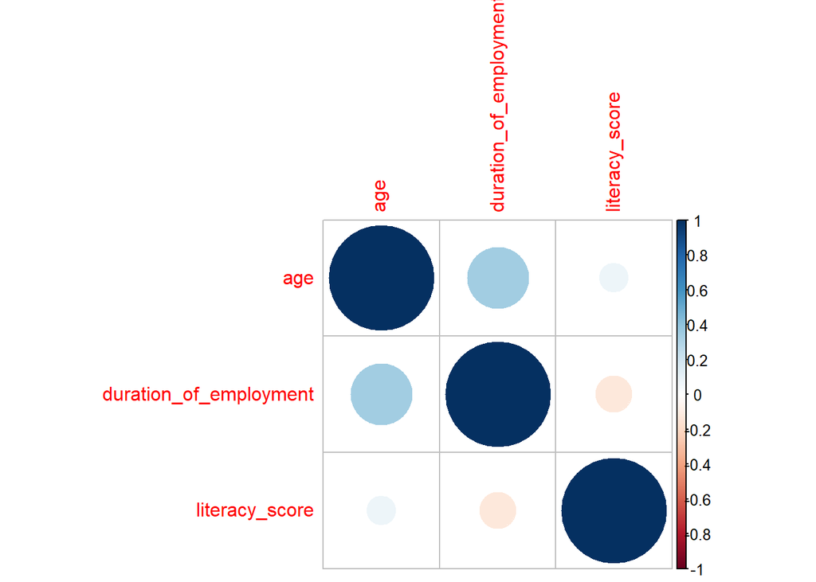

```r
corrplot(cor.data3, method = "circle")
```

Age has shown moderate correlation with 0.34

## 1.4 Perform Linear Regression

### 1.4.1 Univariable Analysis

In the univariable analysis, we will perform simple linear regression ( SLR) for each of the predictors. We aim to select variables that will be included in the multivariable model. in exploratory research, we want to choose only variables with p-values <0.25 and clinically significant to be included in the Multivariable Linear Regression ( MLR) model.

1. Age

   ```r
   sl_age<-lm(literacy_score~age,data = data2)
   summary(sl_age)
   ```

   ```
   Call:
   lm(formula = literacy_score ~ age, data = data2)

   Residuals:
       Min      1Q  Median      3Q     Max
   -24.331  -5.331  -0.845   4.455  52.269

   Coefficients:
               Estimate Std. Error t value Pr(>|t|)
   (Intercept)  86.2138     9.7774   8.818   <2e-16 ***
   age           0.4858     0.3636   1.336    0.183
   ---
   Signif. codes:  0 '***' 0.001 '**' 0.01 '*' 0.05 '.' 0.1 ' ' 1

   Residual standard error: 8.186 on 297 degrees of freedom
   Multiple R-squared:  0.005974,  Adjusted R-squared:  0.002627
   F-statistic: 1.785 on 1 and 297 DF,  p-value: 0.1826
   ```

   ```r
   tidy(sl_age, conf.int= TRUE)
   ```

   ```
   # A tibble: 2 × 7
     term        estimate std.error statistic  p.value conf.low conf.high
     <chr>          <dbl>     <dbl>     <dbl>    <dbl>    <dbl>     <dbl>
   1 (Intercept)   86.2       9.78       8.82 1.01e-16   67.0      105.
   2 age            0.486     0.364      1.34 1.83e- 1   -0.230      1.20
   ```

   ```r
   tbl_regression(sl_age)
   ```

   | **Characteristic** | **Beta** | **95% CI**<sup>1</sup> | **p-value** |
   | --- | --- | --- | --- |
   | age | 0.49 | -0.23, 1.2 | 0.2 |

   <sup>1</sup> CI = Confidence Interval

   2. Gender

   ```r
   sl_gender<-lm(literacy_score~gender ,data = data2)
   summary(sl_gender)
   ```

   ```
   Call:
   lm(formula = literacy_score ~ gender, data = data2)

   Residuals:
       Min      1Q  Median      3Q     Max
   -24.376  -5.376  -1.195   4.624  55.805

   Coefficients:
                Estimate Std. Error t value Pr(>|t|)
   (Intercept)   99.3761     0.7864 126.365   <2e-16 ***
   genderFemale  -0.1814     0.9865  -0.184    0.854
   ---
   Signif. codes:  0 '***' 0.001 '**' 0.01 '*' 0.05 '.' 0.1 ' ' 1

   Residual standard error: 8.21 on 297 degrees of freedom
   Multiple R-squared:  0.0001138, Adjusted R-squared:  -0.003253
   F-statistic: 0.03381 on 1 and 297 DF,  p-value: 0.8542
   ```

   ```r
   tidy(sl_gender, conf.int= TRUE)
   ```

   ```
   # A tibble: 2 × 7
     term         estimate std.error statistic   p.value conf.low conf.high
     <chr>           <dbl>     <dbl>     <dbl>     <dbl>    <dbl>     <dbl>
   1 (Intercept)    99.4       0.786   126.    3.18e-260    97.8     101.
   2 genderFemale   -0.181     0.987    -0.184 8.54e-  1    -2.12      1.76
   ```

   ```r
   tbl_regression(sl_gender)
   ```

   | **Characteristic** | **Beta** | **95% CI**<sup>1</sup> | **p-value** |
   | --- | --- | --- | --- |
   | gender |  |  |  |
   | Male | — | — |  |
   | Female | -0.18 | -2.1, 1.8 | 0.9 |

   <sup>1</sup> CI = Confidence Interval

3. Current Hospital Posting

   ```r
   sl_currenthospital<-lm(literacy_score~current_hospital_posting ,data = data2)
   summary(sl_age)
   ```

   ```
   Call:
   lm(formula = literacy_score ~ age, data = data2)

   Residuals:
       Min      1Q  Median      3Q     Max
   -24.331  -5.331  -0.845   4.455  52.269

   Coefficients:
               Estimate Std. Error t value Pr(>|t|)
   (Intercept)  86.2138     9.7774   8.818   <2e-16 ***
   age           0.4858     0.3636   1.336    0.183
   ---
   Signif. codes:  0 '***' 0.001 '**' 0.01 '*' 0.05 '.' 0.1 ' ' 1

   Residual standard error: 8.186 on 297 degrees of freedom
   Multiple R-squared:  0.005974,  Adjusted R-squared:  0.002627
   F-statistic: 1.785 on 1 and 297 DF,  p-value: 0.1826
   ```

   ```r
   tidy(sl_currenthospital, conf.int= TRUE)
   ```

   ```
   # A tibble: 4 × 7
     term                 estimate std.error statistic   p.value conf.low conf.high
     <chr>                   <dbl>     <dbl>     <dbl>     <dbl>    <dbl>     <dbl>
   1 (Intercept)            98.5       0.834   118.    2.38e-250   96.8      100.
   2 current_hospital_po…    2.86      1.37      2.10  3.69e-  2    0.175      5.55
   3 current_hospital_po…    0.505     1.57      0.322 7.47e-  1   -2.58       3.59
   4 current_hospital_po…    0.503     1.15      0.439 6.61e-  1   -1.75       2.76
   ```

   ```r
   tbl_regression(sl_currenthospital)
   ```

   | **Characteristic** | **Beta** | **95% CI**<sup>1</sup> | **p-value** |
   | --- | --- | --- | --- |
   | current_hospital_posting |  |  |  |
   | HRPZ | — | — |  |
   | HSIP | 2.9 | 0.17, 5.6 | 0.037 |
   | HTM | 0.50 | -2.6, 3.6 | 0.7 |
   | HUSM | 0.50 | -1.8, 2.8 | 0.7 |

   <sup>1</sup> CI = Confidence Interval

4. Duration of emloyment

   ```r
   sl_duration<-lm(literacy_score~duration_of_employment ,data = data2 )
   summary(sl_duration)
   ```

   ```
   Call:
   lm(formula = literacy_score ~ duration_of_employment, data = data2)

   Residuals:
       Min      1Q  Median      3Q     Max
   -23.156  -4.983  -0.654   4.761  54.191

   Coefficients:
                           Estimate Std. Error t value Pr(>|t|)
   (Intercept)            101.47225    1.16035  87.450   <2e-16 ***
   duration_of_employment  -0.16580    0.07949  -2.086   0.0379 *
   ---
   Signif. codes:  0 '***' 0.001 '**' 0.01 '*' 0.05 '.' 0.1 ' ' 1

   Residual standard error: 8.151 on 297 degrees of freedom
   Multiple R-squared:  0.01444,   Adjusted R-squared:  0.01112
   F-statistic:  4.35 on 1 and 297 DF,  p-value: 0.03786
   ```

   ```r
   tidy(sl_duration, conf.int= TRUE)
   ```

   ```
   # A tibble: 2 × 7
     term                 estimate std.error statistic   p.value conf.low conf.high
     <chr>                   <dbl>     <dbl>     <dbl>     <dbl>    <dbl>     <dbl>
   1 (Intercept)           101.       1.16       87.4  5.23e-214   99.2   104.
   2 duration_of_employm…   -0.166    0.0795     -2.09 3.79e-  2   -0.322  -0.00936
   ```

   ```r
   tbl_regression(sl_duration)
   ```

   | **Characteristic** | **Beta** | **95% CI**<sup>1</sup> | **p-value** |
   | --- | --- | --- | --- |
   | duration_of_employment | -0.17 | -0.32, -0.01 | 0.038 |

   <sup>1</sup> CI = Confidence Interval

5. Marital status

   ```r
   sl_marital<-lm(literacy_score~marital_status ,data = data2 )
   summary(sl_marital)
   ```

   ```
   Call:
   lm(formula = literacy_score ~ marital_status, data = data2)

   Residuals:
       Min      1Q  Median      3Q     Max
   -24.194  -5.194  -1.194   4.383  55.383

   Coefficients:
                        Estimate Std. Error t value Pr(>|t|)
   (Intercept)           99.6170     1.1975  83.189   <2e-16 ***
   marital_statusSingle  -0.4226     1.3044  -0.324    0.746
   ---
   Signif. codes:  0 '***' 0.001 '**' 0.01 '*' 0.05 '.' 0.1 ' ' 1

   Residual standard error: 8.209 on 297 degrees of freedom
   Multiple R-squared:  0.0003533, Adjusted R-squared:  -0.003013
   F-statistic: 0.105 on 1 and 297 DF,  p-value: 0.7462
   ```

   ```r
   tidy(sl_marital, conf.int= TRUE)
   ```

   ```
   # A tibble: 2 × 7
     term                 estimate std.error statistic   p.value conf.low conf.high
     <chr>                   <dbl>     <dbl>     <dbl>     <dbl>    <dbl>     <dbl>
   1 (Intercept)            99.6        1.20    83.2   8.11e-208    97.3     102.
   2 marital_statusSingle   -0.423      1.30    -0.324 7.46e-  1    -2.99      2.14
   ```

   ```r
   tbl_regression(sl_marital)
   ```

   | **Characteristic** | **Beta** | **95% CI**<sup>1</sup> | **p-value** |
   | --- | --- | --- | --- |
   | marital_status |  |  |  |
   | Married | — | — |  |
   | Single | -0.42 | -3.0, 2.1 | 0.7 |

   <sup>1</sup> CI = Confidence Interval

6. Previous experience of being bully

   ```r
   sl_experience<-lm(literacy_score~previous_experience_of_being_bullied ,data = data2 )
   summary(sl_experience)
   ```

   ```
   Call:
   lm(formula = literacy_score ~ previous_experience_of_being_bullied,
       data = data2)

   Residuals:
       Min      1Q  Median      3Q     Max
   -25.879  -4.879  -0.553   4.447  54.121

   Coefficients:
                                           Estimate Std. Error t value Pr(>|t|)
   (Intercept)                              98.5529     0.5644 174.604   <2e-16
   previous_experience_of_being_bulliedYes   2.3262     1.0231   2.274   0.0237

   (Intercept)                             ***
   previous_experience_of_being_bulliedYes *
   ---
   Signif. codes:  0 '***' 0.001 '**' 0.01 '*' 0.05 '.' 0.1 ' ' 1

   Residual standard error: 8.14 on 297 degrees of freedom
   Multiple R-squared:  0.01711,   Adjusted R-squared:  0.0138
   F-statistic: 5.169 on 1 and 297 DF,  p-value: 0.0237
   ```

   ```r
   tidy(sl_experience, conf.int= TRUE)
   ```

   ```
   # A tibble: 2 × 7
     term                 estimate std.error statistic   p.value conf.low conf.high
     <chr>                   <dbl>     <dbl>     <dbl>     <dbl>    <dbl>     <dbl>
   1 (Intercept)             98.6      0.564    175.   2.27e-301   97.4       99.7
   2 previous_experience…     2.33     1.02       2.27 2.37e-  2    0.313      4.34
   ```

   ```r
   tbl_regression(sl_experience)
   ```

   | **Characteristic** | **Beta** | **95% CI**<sup>1</sup> | **p-value** |
   | --- | --- | --- | --- |
   | previous_experience_of_being_bullied |  |  |  |
   | No | — | — |  |
   | Yes | 2.3 | 0.31, 4.3 | 0.024 |

   <sup>1</sup> CI = Confidence Interval

7. Family member spouse

   ```r
   sl_family<-lm(literacy_score~family_members_spouse ,data = data2 )
   summary(sl_family)
   ```

   ```
   Call:
   lm(formula = literacy_score ~ family_members_spouse, data = data2)

   Residuals:
       Min      1Q  Median      3Q     Max
   -23.724  -4.724  -0.724   4.276  51.097

   Coefficients:
                            Estimate Std. Error t value Pr(>|t|)
   (Intercept)               98.7239     0.4921 200.601  < 2e-16 ***
   family_members_spouseYes   5.1793     1.5284   3.389 0.000797 ***
   ---
   Signif. codes:  0 '***' 0.001 '**' 0.01 '*' 0.05 '.' 0.1 ' ' 1

   Residual standard error: 8.057 on 297 degrees of freedom
   Multiple R-squared:  0.03722,   Adjusted R-squared:  0.03398
   F-statistic: 11.48 on 1 and 297 DF,  p-value: 0.0007971
   ```

   ```r
   tidy(sl_family, conf.int= TRUE)
   ```

   ```
   # A tibble: 2 × 7
     term                 estimate std.error statistic   p.value conf.low conf.high
     <chr>                   <dbl>     <dbl>     <dbl>     <dbl>    <dbl>     <dbl>
   1 (Intercept)             98.7      0.492    201.   4.02e-319    97.8      99.7
   2 family_members_spou…     5.18     1.53       3.39 7.97e-  4     2.17      8.19
   ```

   ```r
   tbl_regression(sl_family)
   ```

   | **Characteristic** | **Beta** | **95% CI**<sup>1</sup> | **p-value** |
   | --- | --- | --- | --- |
   | family_members_spouse |  |  |  |
   | No | — | — |  |
   | Yes | 5.2 | 2.2, 8.2 | <0.001 |

   <sup>1</sup> CI = Confidence Interval

8. Peers friends

   ```r
   sl_peers<-lm(literacy_score~peers_friends ,data = data2 )
   summary(sl_peers)
   ```

   ```
   Call:
   lm(formula = literacy_score ~ peers_friends, data = data2)

   Residuals:
       Min      1Q  Median      3Q     Max
   -23.632  -4.793  -0.632   4.207  54.207

   Coefficients:
                    Estimate Std. Error t value Pr(>|t|)
   (Intercept)       98.6321     0.5599 176.173   <2e-16 ***
   peers_friendsYes   2.1610     1.0379   2.082   0.0382 *
   ---
   Signif. codes:  0 '***' 0.001 '**' 0.01 '*' 0.05 '.' 0.1 ' ' 1

   Residual standard error: 8.152 on 297 degrees of freedom
   Multiple R-squared:  0.01439,   Adjusted R-squared:  0.01107
   F-statistic: 4.335 on 1 and 297 DF,  p-value: 0.03819
   ```

   ```r
   tidy(sl_peers, conf.int= TRUE)
   ```

   ```
   # A tibble: 2 × 7
     term             estimate std.error statistic   p.value conf.low conf.high
     <chr>               <dbl>     <dbl>     <dbl>     <dbl>    <dbl>     <dbl>
   1 (Intercept)         98.6      0.560    176.   1.63e-302   97.5       99.7
   2 peers_friendsYes     2.16     1.04       2.08 3.82e-  2    0.118      4.20
   ```

   ```r
   tbl_regression(sl_peers)
   ```

   | **Characteristic** | **Beta** | **95% CI**<sup>1</sup> | **p-value** |
   | --- | --- | --- | --- |
   | peers_friends |  |  |  |
   | No | — | — |  |
   | Yes | 2.2 | 0.12, 4.2 | 0.038 |

   <sup>1</sup> CI = Confidence Interval

```r
rsq(sl_age)
```

```
[1] 0.005973705
```

```r
rsq(sl_currenthospital)
```

```
[1] 0.01584071
```

```r
rsq(sl_duration)
```

```
[1] 0.01443512
```

```r
rsq(sl_experience)
```

```
[1] 0.01710795
```

```r
rsq(sl_family)
```

```
[1] 0.03722474
```

```r
rsq(sl_gender)
```

```
[1] 0.0001138381
```

```r
rsq(sl_marital)
```

```
[1] 0.0003532607
```

```r
rsq(sl_peers)
```

```
[1] 0.01438671
```

Summary Table

```r
#create a summary table for each model with confidence intervals
tbl_age <- tbl_regression(sl_age, conf.level = 0.95)

tbl_gender <- tbl_regression(sl_gender, conf.level = 0.95)

tbl_currenthospital <- tbl_regression(sl_currenthospital, conf.level = 0.95)

tbl_duration <- tbl_regression(sl_duration, conf.level = 0.95)

tbl_experience <- tbl_regression(sl_experience, conf.level = 0.95)

tbl_family <- tbl_regression(sl_family, conf.level = 0.95)

tbl_marital <- tbl_regression(sl_marital, conf.level = 0.95)

tbl_peers <- tbl_regression(sl_peers, conf.level = 0.95)


#Combine all tables into one
SLR_table <- tbl_stack(
  list(tbl_age, tbl_peers, tbl_marital, tbl_gender, tbl_family,tbl_experience,tbl_duration,tbl_currenthospital)
) %>%
  as_gt() %>%
  gt::tab_header(
    title = "Simple Linear Regression Model"
  )

#Print the summary table
SLR_table
```

Simple Linear Regression Model

| **Characteristic** | **Beta** | **95% CI**<sup>1</sup> | **p-value** |
| --- | --- | --- | --- |
| age | 0.49 | -0.23, 1.2 | 0.2 |
| peers_friends |  |  |  |
| No | — | — |  |
| Yes | 2.2 | 0.12, 4.2 | 0.038 |
| marital_status |  |  |  |
| Married | — | — |  |
| Single | -0.42 | -3.0, 2.1 | 0.7 |
| gender |  |  |  |
| Male | — | — |  |
| Female | -0.18 | -2.1, 1.8 | 0.9 |
| family_members_spouse |  |  |  |
| No | — | — |  |
| Yes | 5.2 | 2.2, 8.2 | <0.001 |
| previous_experience_of_being_bullied |  |  |  |
| No | — | — |  |
| Yes | 2.3 | 0.31, 4.3 | 0.024 |
| duration_of_employment | -0.17 | -0.32, -0.01 | 0.038 |
| current_hospital_posting |  |  |  |
| HRPZ | — | — |  |
| HSIP | 2.9 | 0.17, 5.6 | 0.037 |
| HTM | 0.50 | -2.6, 3.6 | 0.7 |
| HUSM | 0.50 | -1.8, 2.8 | 0.7 |

<sup>1</sup> CI = Confidence Interval

### 1.4.2 Multivariable Analysis

Model 1

```r
mlr_1<-lm(literacy_score~ duration_of_employment + family_members_spouse +
    current_hospital_posting + previous_experience_of_being_bullied + peers_friends, data = data2)
summary(mlr_1)
```

```
Call:
lm(formula = literacy_score ~ duration_of_employment + family_members_spouse +
    current_hospital_posting + previous_experience_of_being_bullied +
    peers_friends, data = data2)

Residuals:
    Min      1Q  Median      3Q     Max
-23.136  -4.873  -0.020   4.363  48.467

Coefficients:
                                        Estimate Std. Error t value Pr(>|t|)
(Intercept)                             98.72898    1.47587  66.895  < 2e-16
duration_of_employment                  -0.13017    0.07935  -1.641  0.10197
family_members_spouseYes                 4.46020    1.54353   2.890  0.00415
current_hospital_postingHSIP             2.57927    1.34851   1.913  0.05677
current_hospital_postingHTM              0.87073    1.54378   0.564  0.57317
current_hospital_postingHUSM             0.74146    1.12609   0.658  0.51078
previous_experience_of_being_bulliedYes  2.01095    1.01586   1.980  0.04870
peers_friendsYes                         1.11174    1.05039   1.058  0.29075

(Intercept)                             ***
duration_of_employment
family_members_spouseYes                **
current_hospital_postingHSIP            .
current_hospital_postingHTM
current_hospital_postingHUSM
previous_experience_of_being_bulliedYes *
peers_friendsYes
---
Signif. codes:  0 '***' 0.001 '**' 0.01 '*' 0.05 '.' 0.1 ' ' 1

Residual standard error: 7.96 on 291 degrees of freedom
Multiple R-squared:  0.07917,   Adjusted R-squared:  0.05702
F-statistic: 3.574 on 7 and 291 DF,  p-value: 0.001048
```

```r
rsq(mlr_1)
```

```
[1] 0.07916771
```

```r
tidy(mlr_1, conf.int = TRUE)
```

```
# A tibble: 8 × 7
  term                 estimate std.error statistic   p.value conf.low conf.high
  <chr>                   <dbl>     <dbl>     <dbl>     <dbl>    <dbl>     <dbl>
1 (Intercept)            98.7      1.48      66.9   1.02e-178  95.8     102.
2 duration_of_employm…   -0.130    0.0793    -1.64  1.02e-  1  -0.286     0.0260
3 family_members_spou…    4.46     1.54       2.89  4.15e-  3   1.42      7.50
4 current_hospital_po…    2.58     1.35       1.91  5.68e-  2  -0.0748    5.23
5 current_hospital_po…    0.871    1.54       0.564 5.73e-  1  -2.17      3.91
6 current_hospital_po…    0.741    1.13       0.658 5.11e-  1  -1.47      2.96
7 previous_experience…    2.01     1.02       1.98  4.87e-  2   0.0116    4.01
8 peers_friendsYes        1.11     1.05       1.06  2.91e-  1  -0.956     3.18
```

```r
tbl_regression(mlr_1) %>%  add_glance_table(include = c(adj.r.squared)) %>%
  bold_labels() %>% italicize_levels() %>%
  as_gt() %>%
  gt::tab_header(title = "Table 1. Multiple Linear Regression Model 1",
                 subtitle = "Without Interaction")
```

Table 1. Multiple Linear Regression Model 1

Without Interaction

| **Characteristic** | **Beta** | **95% CI**<sup>1</sup> | **p-value** |
| --- | --- | --- | --- |
| duration_of_employment | -0.13 | -0.29, 0.03 | 0.10 |
| family_members_spouse |  |  |  |
| No | — | — |  |
| Yes | 4.5 | 1.4, 7.5 | 0.004 |
| current_hospital_posting |  |  |  |
| HRPZ | — | — |  |
| HSIP | 2.6 | -0.07, 5.2 | 0.057 |
| HTM | 0.87 | -2.2, 3.9 | 0.6 |
| HUSM | 0.74 | -1.5, 3.0 | 0.5 |
| previous_experience_of_being_bullied |  |  |  |
| No | — | — |  |
| Yes | 2.0 | 0.01, 4.0 | 0.049 |
| peers_friends |  |  |  |
| No | — | — |  |
| Yes | 1.1 | -0.96, 3.2 | 0.3 |
| Adjusted R² | 0.057 |  |  |

<sup>1</sup> CI = Confidence Interval

Model 2 with interaction

```r
mlr_2<-lm(literacy_score~ duration_of_employment + family_members_spouse +
    current_hospital_posting + previous_experience_of_being_bullied + current_hospital_posting * peers_friends + peers_friends, data = data2)
summary(mlr_2)
```

```
Call:
lm(formula = literacy_score ~ duration_of_employment + family_members_spouse +
    current_hospital_posting + previous_experience_of_being_bullied +
    current_hospital_posting * peers_friends + peers_friends,
    data = data2)

Residuals:
    Min      1Q  Median      3Q     Max
-23.341  -4.946  -0.034   4.600  47.272

Coefficients:
                                              Estimate Std. Error t value
(Intercept)                                   99.11538    1.53482  64.578
duration_of_employment                        -0.12880    0.07945  -1.621
family_members_spouseYes                       4.42397    1.55014   2.854
current_hospital_postingHSIP                   2.30526    1.69846   1.357
current_hospital_postingHTM                    1.00719    1.71626   0.587
current_hospital_postingHUSM                  -0.11865    1.33047  -0.089
previous_experience_of_being_bulliedYes        1.80133    1.03688   1.737
peers_friendsYes                               0.01111    1.80628   0.006
current_hospital_postingHSIP:peers_friendsYes  0.94493    2.81025   0.336
current_hospital_postingHTM:peers_friendsYes  -1.95424    3.99613  -0.489
current_hospital_postingHUSM:peers_friendsYes  3.01034    2.49465   1.207
                                              Pr(>|t|)
(Intercept)                                    < 2e-16 ***
duration_of_employment                         0.10610
family_members_spouseYes                       0.00463 **
current_hospital_postingHSIP                   0.17576
current_hospital_postingHTM                    0.55776
current_hospital_postingHUSM                   0.92900
previous_experience_of_being_bulliedYes        0.08341 .
peers_friendsYes                               0.99510
current_hospital_postingHSIP:peers_friendsYes  0.73693
current_hospital_postingHTM:peers_friendsYes   0.62519
current_hospital_postingHUSM:peers_friendsYes  0.22853
---
Signif. codes:  0 '***' 0.001 '**' 0.01 '*' 0.05 '.' 0.1 ' ' 1

Residual standard error: 7.97 on 288 degrees of freedom
Multiple R-squared:  0.08646,   Adjusted R-squared:  0.05474
F-statistic: 2.726 on 10 and 288 DF,  p-value: 0.003237
```

```r
rsq(mlr_2)
```

```
[1] 0.08645867
```

Based on literature review, hospital with good advocates for mental health will likely to have a strong and positive peer support. This insteraction were chosen.

```r
tidy(mlr_2)
```

```
# A tibble: 11 × 5
   term                                   estimate std.error statistic   p.value
   <chr>                                     <dbl>     <dbl>     <dbl>     <dbl>
 1 (Intercept)                             99.1       1.53    64.6     2.28e-173
 2 duration_of_employment                  -0.129     0.0795  -1.62    1.06e-  1
 3 family_members_spouseYes                 4.42      1.55     2.85    4.63e-  3
 4 current_hospital_postingHSIP             2.31      1.70     1.36    1.76e-  1
 5 current_hospital_postingHTM              1.01      1.72     0.587   5.58e-  1
 6 current_hospital_postingHUSM            -0.119     1.33    -0.0892  9.29e-  1
 7 previous_experience_of_being_bulliedY…   1.80      1.04     1.74    8.34e-  2
 8 peers_friendsYes                         0.0111    1.81     0.00615 9.95e-  1
 9 current_hospital_postingHSIP:peers_fr…   0.945     2.81     0.336   7.37e-  1
10 current_hospital_postingHTM:peers_fri…  -1.95      4.00    -0.489   6.25e-  1
11 current_hospital_postingHUSM:peers_fr…   3.01      2.49     1.21    2.29e-  1
```

```r
tbl_regression(mlr_2) %>%  add_glance_table(include = c(adj.r.squared)) %>%
  bold_labels() %>% italicize_levels() %>% add_n() %>%
  as_gt() %>%
  gt::tab_header(title = "Multiple Linear Regression Model",
                 subtitle = "With Interaction")
```

Multiple Linear Regression Model

With Interaction

| **Characteristic** | **N** | **Beta** | **95% CI**<sup>1</sup> | **p-value** |
| --- | --- | --- | --- | --- |
| duration_of_employment | 299 | -0.13 | -0.29, 0.03 | 0.11 |
| family_members_spouse | 299 |  |  |  |
| No |  | — | — |  |
| Yes |  | 4.4 | 1.4, 7.5 | 0.005 |
| current_hospital_posting | 299 |  |  |  |
| HRPZ |  | — | — |  |
| HSIP |  | 2.3 | -1.0, 5.6 | 0.2 |
| HTM |  | 1.0 | -2.4, 4.4 | 0.6 |
| HUSM |  | -0.12 | -2.7, 2.5 | >0.9 |
| previous_experience_of_being_bullied | 299 |  |  |  |
| No |  | — | — |  |
| Yes |  | 1.8 | -0.24, 3.8 | 0.083 |
| peers_friends | 299 |  |  |  |
| No |  | — | — |  |
| Yes |  | 0.01 | -3.5, 3.6 | >0.9 |
| current_hospital_posting * peers_friends | 299 |  |  |  |
| HSIP * Yes |  | 0.94 | -4.6, 6.5 | 0.7 |
| HTM * Yes |  | -2.0 | -9.8, 5.9 | 0.6 |
| HUSM * Yes |  | 3.0 | -1.9, 7.9 | 0.2 |
| Adjusted R² |  | 0.055 |  |  |

<sup>1</sup> CI = Confidence Interval

### 1.4.3 Model Comparison

```r
anova(mlr_1,mlr_2)
```

```
Analysis of Variance Table

Model 1: literacy_score ~ duration_of_employment + family_members_spouse +
    current_hospital_posting + previous_experience_of_being_bullied +
    peers_friends
Model 2: literacy_score ~ duration_of_employment + family_members_spouse +
    current_hospital_posting + previous_experience_of_being_bullied +
    current_hospital_posting * peers_friends + peers_friends
  Res.Df   RSS Df Sum of Sq      F Pr(>F)
1    291 18438
2    288 18292  3    145.99 0.7662 0.5138
```

Model Assessment We took Model 1 (MLR model without interaction) as our preliminary model

### 1.4.4 Assessment of model fitness

```r
prelim.final.m <- lm (literacy_score~ duration_of_employment + family_members_spouse + current_hospital_posting + peers_friends + current_hospital_posting + previous_experience_of_being_bullied, data = data2)
rsq(prelim.final.m)
```

```
[1] 0.07916771
```

```r
tidy(prelim.final.m)
```

```
# A tibble: 8 × 5
  term                                    estimate std.error statistic   p.value
  <chr>                                      <dbl>     <dbl>     <dbl>     <dbl>
1 (Intercept)                               98.7      1.48      66.9   1.02e-178
2 duration_of_employment                    -0.130    0.0793    -1.64  1.02e-  1
3 family_members_spouseYes                   4.46     1.54       2.89  4.15e-  3
4 current_hospital_postingHSIP               2.58     1.35       1.91  5.68e-  2
5 current_hospital_postingHTM                0.871    1.54       0.564 5.73e-  1
6 current_hospital_postingHUSM               0.741    1.13       0.658 5.11e-  1
7 peers_friendsYes                           1.11     1.05       1.06  2.91e-  1
8 previous_experience_of_being_bulliedYes    2.01     1.02       1.98  4.87e-  2
```

A diagnostic Plot

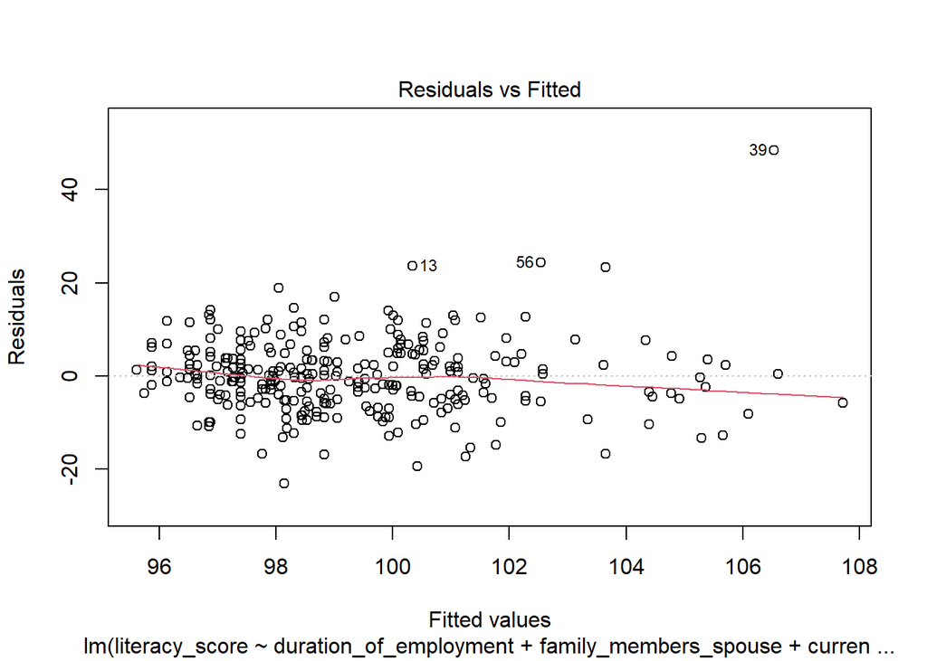

```r
plot(prelim.final.m,which=1)
```